# Multivariate covariance generalized linear models for analysis of experimental data

Phd. Wagner Hugo Bonat & Dr. Walmes Marques Zeviani

July 24-28 2017

# Multivariate covariance generalized linear models for analysis of experimental data

# Introduction

### What is this course about

- Often in experimental studies many outcomes are collected simultaneously.
- Sometimes the outcomes or response variables are of mixed types.
- Methods for the separate analysis of such outcomes are well established in the literature.
  - Continuous and symmetric data: linear regression models.
  - Continuous and assymetric data: gamma and inverse Gaussian regression models.
  - Semi-continuous data: Tweedie and zero-inflated regression models.
  - Counting data: Poisson, negative binomial, Poisson-Tweedie and $\ldots$ regression models.
  - Bounded data: logistic, probit, beta, simplex and $\ldots$ regression models.

### Main goal

- Purpose of this course is to present the state of art in

Multivariate analysis of experimental data based on the  
multivariate covariance generalized linear models class.

### Learnings objectives

- Goals: After this course participants will be able to
  - identify settings in which a multivariate analysis is required,
  - construct and fit an appropriate multivariate model, and
  - correctly interpret the obtained results.
- The course will be explanatory rather than mathematically rigorous
  - emphasis is given on sufficient detail in order for participants to obtain a clear view on the multivariate models and how they should be used in practice.

# Agenda

- **Part I: Multivariate analysis of Gaussian data (MANOVA)**
  - Motivational datasets and research questions.
  - General linear model.
  - Estimation and Inference (least squares and MLE).
  - General linear hypotheses.
  - Multivariate hypotheses tests.
  - Computational implementation in $\texttt{R}$.
  - $\texttt{lm()}$ and $\texttt{manova()}$ functions.
  - MANOVA as a McGLM.
  - $\texttt{mcglm()}$ function.
  - Worked examples.
  - Assumptions and limitations.
- **Part II: Multivariate analysis of non-Gaussian data (McGLMs)**
  - Dealing with non-Gaussian data: Multivariate generalized linear models (MGLMs).
  - Dealing with non-independent data: Linear covariance models (LCMs).
  - Specifying the matrix linear predictor:
    - Repeated measures.
    - Longitudinal studies.
    - Mixed models.
  - Estimation and Inference.
  - General linear hypotheses tests.
  - MANOVA-like test for non-Gaussian data.
  - Worked examples.
  - Discussions and extensions.

# Motivational data sets

### $\texttt{iris}$ data set

- $\texttt{iris}$ data set was collected by Anderson (1935) on three species of irises in the Gaspé Peninsula of Quebec, Canada.
- This data set was employed by R. A. Fisher (1936) to introduce the method of discriminant analysis.
- Easily available in $\texttt{R}$ through $\texttt{data(iris)}$.
- Four response variables representing measurements (in cm) of parts of the flowers (length and width of sepal and petal).
- One experimental factor with three levels ($\texttt{setosa}$, $\texttt{versicolor}$ and $\texttt{virginica}$) representing the species of iris.
- How the species are related with flowers size?
- Size is not a really precise response variable and can be understood as a function of the four measured response variables.

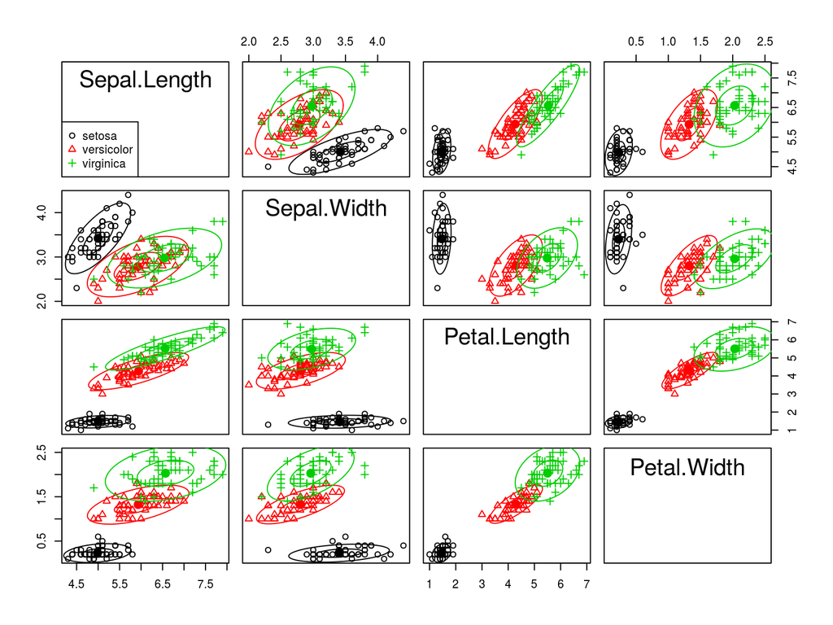

```r
data(iris)
scatterplotMatrix(~ Sepal.Length + Sepal.Width + Petal.Length + Petal.Width | Species,
                  data = iris, smooth = FALSE, reg.line = FALSE, ellipse = TRUE,
                  by.groups = TRUE, diagonal = "none", legend.pos = "bottomleft")
```

### $\texttt{soya}$ data set

- Experiment carried out in a vegetation house with soybeans.
- Two plants by plot with three levels of the factor amount of water in the soil ($\texttt{water}$) and five levels of potassium fertilization ($\texttt{pot}$).
- The plots were arranged in five blocks ($\texttt{block}$).
- Three response variables were measured, namely, grain yield, number of seeds and number of viable peas per plant.
- The main goal is to assess the effect of the experimental factors on the soya $\textbf{yield}$.
- Soya $\textbf{yield}$ is only indirectly measured through the three measured response variables.
- Response variables are of mixed types, i.e. grain yield is a continuous outcome while number of seeds and number of viable peas per plant are examples of count and binomial response variables.
- Data set is available in $\texttt{R}$ through the $\texttt{mcglm}$ package.

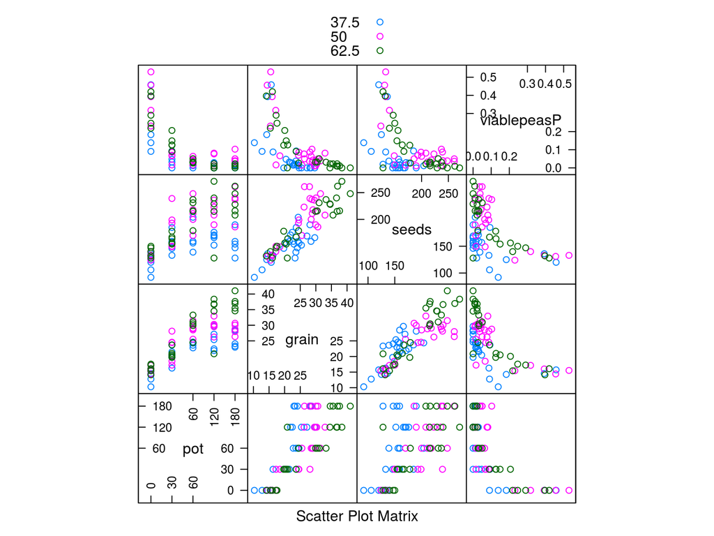

```r
data(soya)
soya$viablepeasP <- soya$viablepeas / soya$totalpeas
splom(~soya[, c(1,4:5,8)], groups = soya$water, layout= c(NA, 1),
      type = c("p"), auto.key= TRUE)
```

### Motivation and research questions

- Models of nature and human behavior must often account for multiple, inter-related variables that are conceptualized simultaneously or over time.
- Often in the same experiment more than one response variables are measured simultaneously.
- Multivariate experiments are common when we have a set of variables to describe an attribute or latent variable.
  - Size variables (weight, height, width, diameter, etc).
  - Soil contents (P, K, pH, Ca, Mg, CTC, etc).
  - Personality traits (example HERE).
- In general, the research questions are related to all or a combination of the response variables.
- Examples of research questions.
  - Which is the best (set of) variable to measure?
  - What are the main effects of the covariates or experimental factors?
  - What are the interaction among experimental factors?
  - What is the strenght of association/correlation between response variables?
  - Which response variables are more affected by the experimental factors?

# **Part I: Multivariate analysis of Gaussian data**

- General linear model

$$\begin{pmatrix}
Y_{11} & \ldots & Y_{1R}\\
\vdots & \ddots & \vdots \\
Y_{N1} & \ldots & Y_{NR}
\end{pmatrix} =
\begin{pmatrix}
x_{11} & \ldots & x_{1k}\\
\vdots & \ddots & \vdots \\
x_{N1} & \ldots & x_{Nk}
\end{pmatrix} \begin{pmatrix}
\beta_{01} & \ldots & \beta_{0R}\\
\vdots & \ddots & \vdots \\
\beta_{k1} & \ldots & \beta_{kR}
\end{pmatrix} + \begin{pmatrix}
\epsilon_{11} & \ldots & \epsilon_{1R}\\
\vdots & \ddots & \vdots \\
\epsilon_{N1} & \ldots & \epsilon_{NR}
\end{pmatrix}$$

- Matrix notation

$$\mathrm{Y} = \mathrm{X}\mathbf{B} + \mathbf{E}$$

- $\mathrm{Y}$ is a matrix of $N$ observations on $R$ response variables.
- $\mathrm{X}$ is an $(N \times k)$ model matrix with collumns for $k$ regressors (experimental factors).
- $\mathrm{B}$ is a $(k \times R)$ matrix of regression coefficients.
- $\mathrm{E}$ is an $(N \times R)$ matrix of errors, such that $\epsilon^{\top}_i \sim N_{R}(\mathbf{0}, \Sigma)$.
- $\Sigma$ is an ($R \times R$) covariance matrix, constant across observations, i.e.

$$\Sigma = \begin{pmatrix}
\sigma_{11} & \ldots & \sigma_{1R} \\
\vdots & \ddots & \vdots \\
\sigma_{R1} & \ldots & \sigma_{RR}
\end{pmatrix}.$$

- Least square estimators for regression coefficients

$$\hat{\mathrm{B}} = (\mathrm{X}^{\top}\mathrm{X})^{-1}\mathrm{X}^{\top}\mathrm{Y}.$$

- $\Sigma$ can be estimated by the empirical covariance matrix.

$$\hat{\Sigma} = \frac{(\mathrm{Y} - \mathrm{X} \hat{\mathrm{B}} )^{\top}(\mathrm{Y} - \mathrm{X} \hat{\mathrm{B}})}{n}$$

# R code

```r
data(iris)
head(iris)
```

```
##   Sepal.Length Sepal.Width Petal.Length Petal.Width Species
## 1          5.1         3.5          1.4         0.2  setosa
## 2          4.9         3.0          1.4         0.2  setosa
## 3          4.7         3.2          1.3         0.2  setosa
## 4          4.6         3.1          1.5         0.2  setosa
## 5          5.0         3.6          1.4         0.2  setosa
## 6          5.4         3.9          1.7         0.4  setosa
```

```r
# Response variable matrix
Y <- as.matrix(iris[,1:4],ncol = 4, nrow = 150)

# Design matrix
X = model.matrix(~Species, data = iris)

# Regression coefficients
B <- solve(tcrossprod(t(X)))%*%t(X)%*%Y
B
```

```
##                   Sepal.Length Sepal.Width Petal.Length Petal.Width
## (Intercept)              5.006       3.428        1.462       0.246
## Speciesversicolor        0.930      -0.658        2.798       1.080
## Speciesvirginica         1.582      -0.454        4.090       1.780
```

```r
# Covariance matrix
Sigma <- t(Y - X%*%B)%*%(Y - X%*%B)/dim(iris)[1]
Sigma
```

```
##              Sepal.Length Sepal.Width Petal.Length Petal.Width
## Sepal.Length   0.25970800  0.09086667   0.16416400  0.03763333
## Sepal.Width    0.09086667  0.11308000   0.05413867  0.03205600
## Petal.Length   0.16416400  0.05413867   0.18148400  0.04181200
## Petal.Width    0.03763333  0.03205600   0.04181200  0.04104400
```

```r
# Correlation matrix
cov2cor(Sigma)
```

```
##              Sepal.Length Sepal.Width Petal.Length Petal.Width
## Sepal.Length    1.0000000   0.5302358    0.7561642   0.3645064
## Sepal.Width     0.5302358   1.0000000    0.3779162   0.4705346
## Petal.Length    0.7561642   0.3779162    1.0000000   0.4844589
## Petal.Width     0.3645064   0.4705346    0.4844589   1.0000000
```

### Model-based approach

- Let $\mathcal{Y} = (\mathbf{Y}_1^T, \ldots, \mathbf{Y}_R^T)^T$ be the stacked vector $(NR \times 1)$ of the outcome matrix $\mathbf{Y}_{N \times R}$ by columns.
- Let $\mathbf{X} = \mathrm{Bdiag}(\mathrm{X}_1, \ldots, \mathrm{X}_R)$ be an $(NR \times k)$ design matrix, where the operator $\mathrm{Bdiag}$ denotes a block diagonal matrix whose entries are given by $\mathrm{X}$.
- We can easily extend to the case where $X$ is different for each response variable.
- Let $\boldsymbol{\beta} = (\boldsymbol{\beta}_1^T, \ldots, \boldsymbol{\beta}_R^T)^T$ be the stacked vector $(K \times 1)$ of the regression parameters matrix $\mathbf{B}$ by columns.
- General linear model

$$\mathcal{Y} \sim \mathrm{N}_{NR}(\mathbf{X}\boldsymbol{\beta}, \Sigma \otimes \mathrm{I})$$
where $\mathrm{I}$ denotes an $(N \times N)$ identity matrix and $\otimes$ denotes the Kronecker product.

- Equivalently, we have

$$\mathcal{Y} = \mathbf{X}\boldsymbol{\beta} + \boldsymbol{\epsilon}$$
where $\boldsymbol{\epsilon} \sim \mathrm{N}_{NR}(\boldsymbol{0},\Sigma \otimes \mathrm{I})$.

- It is trivial to show that

$$\mathrm{E}(\mathcal{Y}) = \mathbf{X}\boldsymbol{\beta}$$
$$\mathrm{var}(\mathcal{Y}) = \Sigma \otimes \mathrm{I}.$$

- For simplicity denote $\Omega = \Sigma \otimes \mathrm{I}.$

### Maximum likelihood estimation for the general linear model

- Likelihood function

$$L(\boldsymbol{\beta}, \Omega) = (2\pi)^{ -\frac{NR}{2} } |\Omega|^{-\frac{1}{2}} \exp \left \{ -\frac{1}{2}(\mathcal{Y} - \mathbf{X}\boldsymbol{\beta})^{\top}\Omega^{-1} (\mathcal{Y} - \mathbf{X}\boldsymbol{\beta}) \right \}.$$
- Log-likelihood function

$$l(\boldsymbol{\beta}, \Omega) = -\frac{NR}{2}\log(2\pi) -\frac{1}{2}\log |\Omega| -\frac{1}{2}(\mathcal{Y} - \mathbf{X}\boldsymbol{\beta})^{\top}\Omega^{-1} (\mathcal{Y} - \mathbf{X}\boldsymbol{\beta}).$$

- Score function for $\boldsymbol{\beta}$ is given by

$$U_{\boldsymbol{\beta}}(\boldsymbol{\beta}, \Omega) = \frac{\partial l(\boldsymbol{\beta}, \Omega)}{\partial \boldsymbol{\beta}} = \mathbf{X}^{\top} \Omega^{-1}(\mathcal{Y} - \mathbf{X}\boldsymbol{\beta}).$$

- Maximum likelihood estimator (MLE) for $\boldsymbol{\beta}$

$$\hat{\boldsymbol{\beta}} = (\mathbf{X}^{\top}\mathbf{X})^{-1}\mathbf{X}^{\top}\mathcal{Y}.$$

- Fisher Information Matrix for $\boldsymbol{\beta}$

$$\mathcal{F}_{\boldsymbol{\beta}} = \mathbf{X}^{\top}\Omega^{-1}\mathbf{X}.$$

- Let $\boldsymbol{\sigma}$ be the stacked vector $(Q \times 1)$ of the covariance parameters matrix $\Omega$ by columns.
- We introduce the notation $\Omega(\boldsymbol{\sigma})$ to emphasize that $\Omega$ is composed by the components of $\boldsymbol{\sigma}$.
- Score function for the component $\sigma_{i}$ is given by

$$U_{\sigma_{i}}(\boldsymbol{\beta}, \Omega(\boldsymbol{\sigma})) =
\frac{\partial l(\boldsymbol{\beta}, \Omega(\boldsymbol{\sigma}))}{\partial \sigma_{i}} =
-\frac{1}{2}\left \{ \Omega(\boldsymbol{\sigma})^{-1} - \Omega(\boldsymbol{\sigma})^{-1}(\mathcal{Y} - \mathbf{X}\boldsymbol{\beta})(\mathcal{Y} - \mathbf{X}\boldsymbol{\beta})^{\top}\Omega(\boldsymbol{\sigma})^{-1} \right \}
\frac{\partial \Omega(\boldsymbol{\sigma})}{\partial \sigma_{i}}.$$

- After some calculation, we can show that the MLE for $\Omega$ is given by

$$\hat{\Omega} = \hat{\Sigma} \otimes \mathrm{I},$$
where $\hat{\Sigma}$ is the empirical covariance matrix. - The $(i,j)$ entry of the Fisher Information matrix for the components $\sigma_i$ and $\sigma_j$ is given by

$$\mathcal{F}_{\sigma_i \sigma_j} = \frac{1}{2}\mathrm{tr}(\mathrm{W}_{\sigma_i}\Omega(\boldsymbol{\sigma}) \mathrm{W}_{\sigma_j}\Omega(\boldsymbol{\sigma})),$$
where $\mathrm{W}_{\sigma_i} = -\frac{\partial \Omega(\boldsymbol{\sigma})^{-1}}{\partial \sigma_i}$. - Let $\mathcal{F}_{\boldsymbol{\sigma}}$ be the $Q \times Q$ Fisher information matrix for the vector $\boldsymbol{\sigma}$. - It is easy to show that $\boldsymbol{\beta}$ and $\boldsymbol{\sigma}$ are orthogonal. - Fisher information matrix for $\boldsymbol{\theta} = (\boldsymbol{\beta}^{\top}, \boldsymbol{\sigma}^{\top})^{\top}$ is given by

$$\mathcal{F}_{\boldsymbol{\theta}} = \begin{pmatrix}
\mathcal{F}_{\boldsymbol{\beta}} & \boldsymbol{0} \\
\boldsymbol{0} & \mathcal{F}_{\boldsymbol{\sigma}}
\end{pmatrix}.$$

- Asymptotic distribution of the MLE

$$\hat{\boldsymbol{\theta}} \sim N_{P+Q}(\boldsymbol{\theta},\mathcal{F}_{\boldsymbol{\theta}}^{-1}).$$

# R code

```r
# Loading data set
data(iris)

# Fitting the model
fit1 <- lm(cbind(Sepal.Length, Sepal.Width, Petal.Length, Petal.Width) ~ Species, data = iris)

# Regression coefficients
coef(fit1)
```

```
##                   Sepal.Length Sepal.Width Petal.Length Petal.Width
## (Intercept)              5.006       3.428        1.462       0.246
## Speciesversicolor        0.930      -0.658        2.798       1.080
## Speciesvirginica         1.582      -0.454        4.090       1.780
```

```r
# Covariance matrix
cov(residuals(fit1))
```

```
##              Sepal.Length Sepal.Width Petal.Length Petal.Width
## Sepal.Length   0.26145101  0.09147651   0.16526577  0.03788591
## Sepal.Width    0.09147651  0.11383893   0.05450201  0.03227114
## Petal.Length   0.16526577  0.05450201   0.18270201  0.04209262
## Petal.Width    0.03788591  0.03227114   0.04209262  0.04131946
```

- It provides exactly the same estimates that separate calls to the $\texttt{lm()}$ function.
- Standard errors for regression coefficients are available through the function $\texttt{vcov()}$.
- Standard errors for covariance coefficients are not available.

### Multivariate hypotheses tests

- Standard approaches are based on the decomposition of the total sum of squares and cross products (SSP) into regression and residuals, i.e.

$$\begin{align}
\mathrm{SSP}_{T} &=& \mathrm{Y}^{\top} \mathrm{Y} - N \bar{\mathrm{Y}}\bar{\mathrm{Y}}^{\top} \\
&=& \hat{\mathrm{E}}^{\top} \hat{\mathrm{E}} + (\hat{\mathrm{Y}}^{\top} \hat{\mathrm{Y}} - N \bar{\mathrm{Y}}\bar{\mathrm{Y}}^{\top}) \\
&=& \mathrm{SSP}_{R} + \mathrm{SSP}_{Reg},
\end{align}$$

where $\bar{\mathrm{Y}}$ is the $(R \times 1)$ vector of means for the response variables.

- $\hat{\mathrm{Y}} = \mathrm{X} \hat{\mathrm{B}}$ is the matrix of fitted values.
- $\hat{\mathrm{E}} = \mathrm{Y} - \hat{\mathrm{Y}}$ is the matrix of residuals.
- Let $\mathrm{SSP}_H$ denotes the incremental $\mathrm{SSP}$ matrix for a hypothesis.
- Multivariate tests are based on the $R$ eigenvalues of $\mathrm{SSP}_H \mathrm{SSP}_R^{-1}$.
- Let $\boldsymbol{\lambda}$ denote the eigenvalues of $\mathrm{SSP}_H \mathrm{SSP}_R^{-1}$, that is, the values of $\boldsymbol{\lambda}$ for which

$$| \mathrm{SSP}_H \mathrm{SSP}_R^{-1} - \boldsymbol{\lambda} \mathrm{I} | = 0.$$

- The four most employed multivariate test statistics are functions of $\boldsymbol{\lambda}$:
  - Pillai-Bartlett Trace, $T_{PB} = \sum_{i = 1}^{R} \frac{\lambda_i}{(1- \lambda_i)}.$
  - Hotelling-Lawley Trace, $T_{HL} = \sum_{i = 1}^{R} \lambda_i.$
  - Wilk’s Lambda, $\Lambda = \prod_{i=1}^{R} \frac{1}{1+\lambda_i}.$
  - Roy’s maximum root, $T_{R} = \lambda_1.$

# Future research

- Implement multivariate hypothesis tests for McGLM.
- Explore the multiple design multivariate linear models.
- A set of functions to communicate with `multcomp::glht()`.

# Next topics

- Reapeted measures design.
- Profile analysis.
- Analysis for the canonical variates .
- Multiple comparisons procedures.
- Checking model assumptions.
- Multiple design linear regression models.

Thank you!